# Chapter 2 Exercises

# Applied

8.

```r
college <- read.csv('College.csv')
row.names(college) <- college[,1]
college <- college[,-1]
names(college)
```

```
##  [1] "Private"     "Apps"        "Accept"      "Enroll"      "Top10perc"
##  [6] "Top25perc"   "F.Undergrad" "P.Undergrad" "Outstate"    "Room.Board"
## [11] "Books"       "Personal"    "PhD"         "Terminal"    "S.F.Ratio"
## [16] "perc.alumni" "Expend"      "Grad.Rate"
```

```r
print(sum(is.na(college[,]))) # No NAs
```

```
## [1] 0
```

```r
summary(college)
```

```
##  Private        Apps           Accept          Enroll       Top10perc
##  No :212   Min.   :   81   Min.   :   72   Min.   :  35   Min.   : 1.0
##  Yes:565   1st Qu.:  776   1st Qu.:  604   1st Qu.: 242   1st Qu.:15.0
##            Median : 1558   Median : 1110   Median : 434   Median :23.0
##            Mean   : 3002   Mean   : 2019   Mean   : 780   Mean   :27.6
##            3rd Qu.: 3624   3rd Qu.: 2424   3rd Qu.: 902   3rd Qu.:35.0
##            Max.   :48094   Max.   :26330   Max.   :6392   Max.   :96.0
##    Top25perc      F.Undergrad     P.Undergrad       Outstate
##  Min.   :  9.0   Min.   :  139   Min.   :    1   Min.   : 2340
##  1st Qu.: 41.0   1st Qu.:  992   1st Qu.:   95   1st Qu.: 7320
##  Median : 54.0   Median : 1707   Median :  353   Median : 9990
##  Mean   : 55.8   Mean   : 3700   Mean   :  855   Mean   :10441
##  3rd Qu.: 69.0   3rd Qu.: 4005   3rd Qu.:  967   3rd Qu.:12925
##  Max.   :100.0   Max.   :31643   Max.   :21836   Max.   :21700
##    Room.Board       Books         Personal         PhD
##  Min.   :1780   Min.   :  96   Min.   : 250   Min.   :  8.0
##  1st Qu.:3597   1st Qu.: 470   1st Qu.: 850   1st Qu.: 62.0
##  Median :4200   Median : 500   Median :1200   Median : 75.0
##  Mean   :4358   Mean   : 549   Mean   :1341   Mean   : 72.7
##  3rd Qu.:5050   3rd Qu.: 600   3rd Qu.:1700   3rd Qu.: 85.0
##  Max.   :8124   Max.   :2340   Max.   :6800   Max.   :103.0
##     Terminal       S.F.Ratio     perc.alumni       Expend
##  Min.   : 24.0   Min.   : 2.5   Min.   : 0.0   Min.   : 3186
##  1st Qu.: 71.0   1st Qu.:11.5   1st Qu.:13.0   1st Qu.: 6751
##  Median : 82.0   Median :13.6   Median :21.0   Median : 8377
##  Mean   : 79.7   Mean   :14.1   Mean   :22.7   Mean   : 9660
##  3rd Qu.: 92.0   3rd Qu.:16.5   3rd Qu.:31.0   3rd Qu.:10830
##  Max.   :100.0   Max.   :39.8   Max.   :64.0   Max.   :56233
##    Grad.Rate
##  Min.   : 10.0
##  1st Qu.: 53.0
##  Median : 65.0
##  Mean   : 65.5
##  3rd Qu.: 78.0
##  Max.   :118.0
```

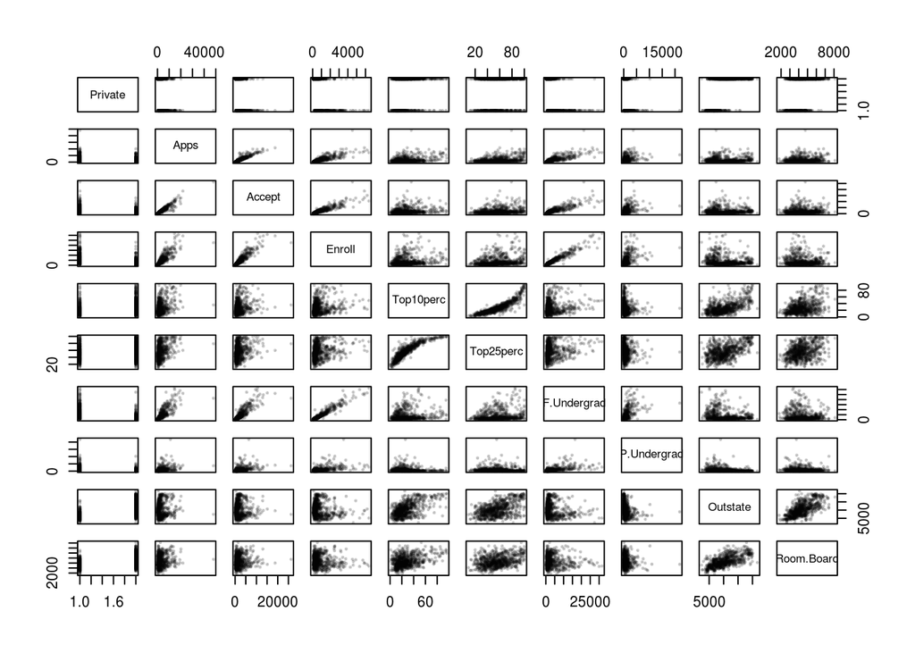

```r
pairs(college[,1:10], pch=20, cex=.5, col=rgb(0,0,0,0.15)) # pairs plot with transparency
```

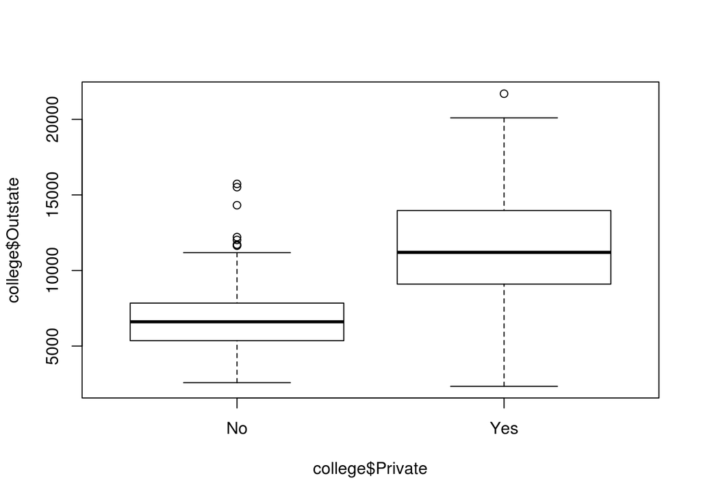

```r
plot(college$Outstate ~ college$Private)
```

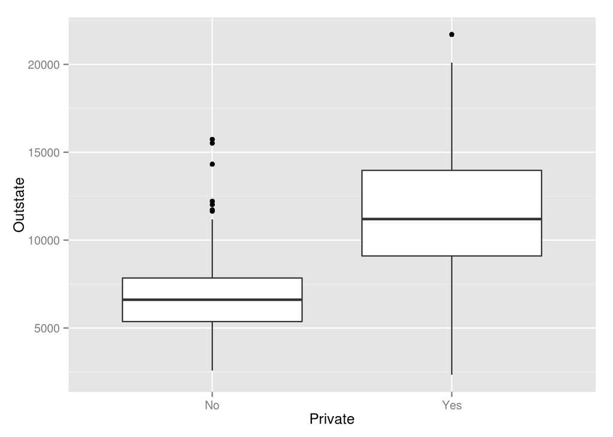

```r
ggplot(college, aes(Private, Outstate)) + geom_boxplot()
```

```r
college$Elite <- "not Elite"
college$Elite[ college$Top10perc > 50] <- "Elite"
college$Elite <- as.factor(college$Elite)
summary(college$Elite)
```

```
##     Elite not Elite
##        78       699
```

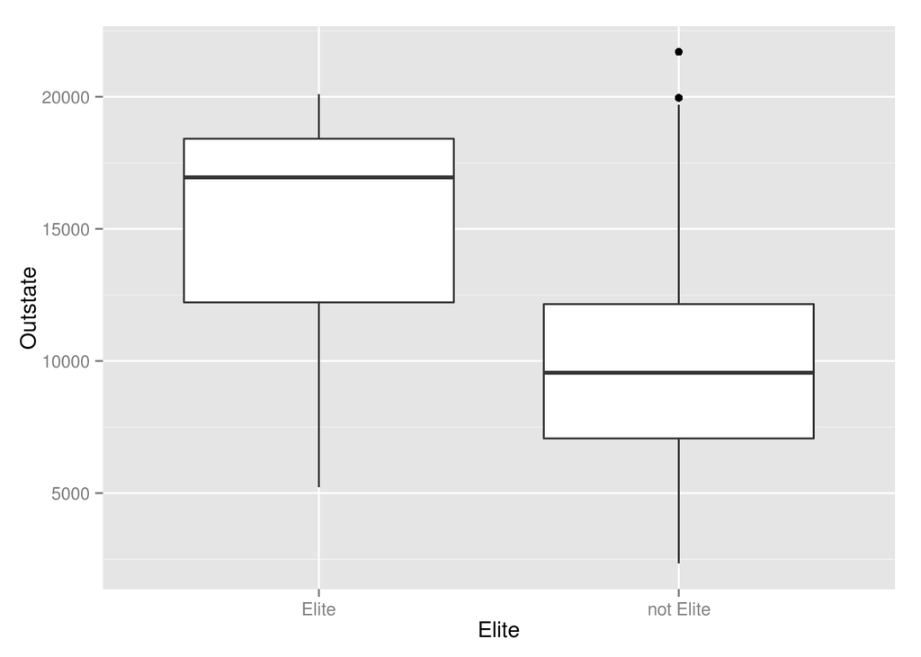

```r
ggplot(college, aes(Elite, Outstate)) + geom_boxplot()
```

```
## stat_bin: binwidth defaulted to range/30. Use 'binwidth = x' to adjust this.
## stat_bin: binwidth defaulted to range/30. Use 'binwidth = x' to adjust this.
```

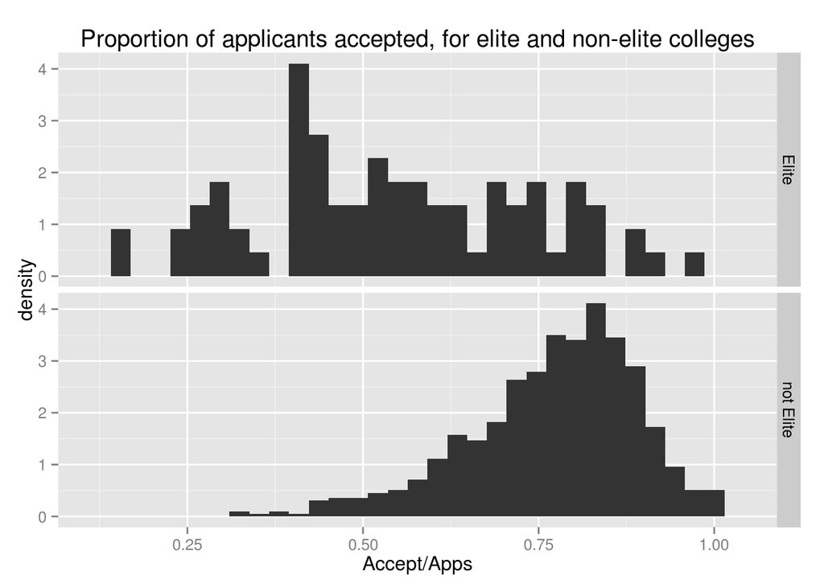

```r
ggplot(college, aes(Accept / Apps)) + geom_histogram(aes(y=..density..)) +
    facet_grid(Elite ~ .) +
    ggtitle(label = "Proportion of applicants accepted, for elite and non-elite colleges")
```

9.

```r
auto <- read.csv('Auto.csv', na.strings='?')
cc <- complete.cases(auto)
sum(!cc) # 5 rows have missing horsepower
```

```
## [1] 5
```

```r
auto <- auto[cc,]
str(auto)
```

```
## 'data.frame':    392 obs. of  9 variables:
##  $ mpg         : num  18 15 18 16 17 15 14 14 14 15 ...
##  $ cylinders   : int  8 8 8 8 8 8 8 8 8 8 ...
##  $ displacement: num  307 350 318 304 302 429 454 440 455 390 ...
##  $ horsepower  : int  130 165 150 150 140 198 220 215 225 190 ...
##  $ weight      : int  3504 3693 3436 3433 3449 4341 4354 4312 4425 3850 ...
##  $ acceleration: num  12 11.5 11 12 10.5 10 9 8.5 10 8.5 ...
##  $ year        : int  70 70 70 70 70 70 70 70 70 70 ...
##  $ origin      : int  1 1 1 1 1 1 1 1 1 1 ...
##  $ name        : Factor w/ 304 levels "amc ambassador brougham",..: 49 36 231 14 161 141 54 223 241 2 ...
```

```r
# auto$cylinders <- factor(auto$cylinders) # not sure whether should be numeric or factor
auto$origin <- factor(auto$origin)
```

Types of predictors (I assume we are predicting mpg):

Quantitative: cylinders (?), displacement, horsepower, weight, acceleration, year

Qualitative: cylinders, origin, name

Cylinders, Displacement, Horsepower, and Weight are all positively correlated with each other but negatively with MPG. It looks like all of the predictors should be investigated to see whether they should be included in a model.

```r
# shows the range and mean of each quantitative predictor
summary(auto[,c(3,4,5,6,7)])[c(1,4,6),]
```

```
##   displacement     horsepower          weight        acceleration
##  "Min.   : 68  " "Min.   : 46.0  " "Min.   :1613  " "Min.   : 8.0  "
##  "Mean   :194  " "Mean   :104.5  " "Mean   :2978  " "Mean   :15.5  "
##  "Max.   :455  " "Max.   :230.0  " "Max.   :5140  " "Max.   :24.8  "
##       year
##  "Min.   :70  "
##  "Mean   :76  "
##  "Max.   :82  "
```

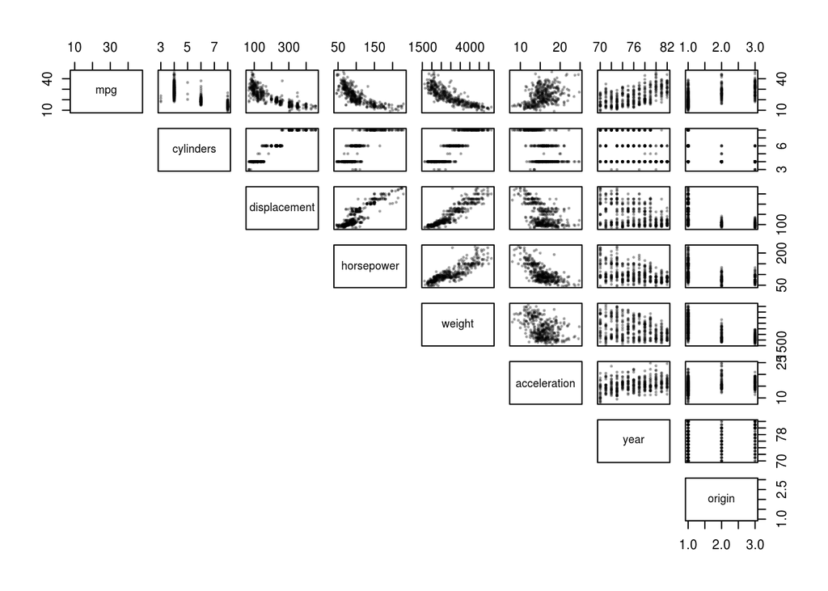

```r
pairs(auto[,-9], lower.panel = {}, pch=20, cex=.5, col=rgb(0,0,0,.25))
```

Displacement, weight, hp, horsepower are skewed. Mpg and Acceleration are roughly normal.

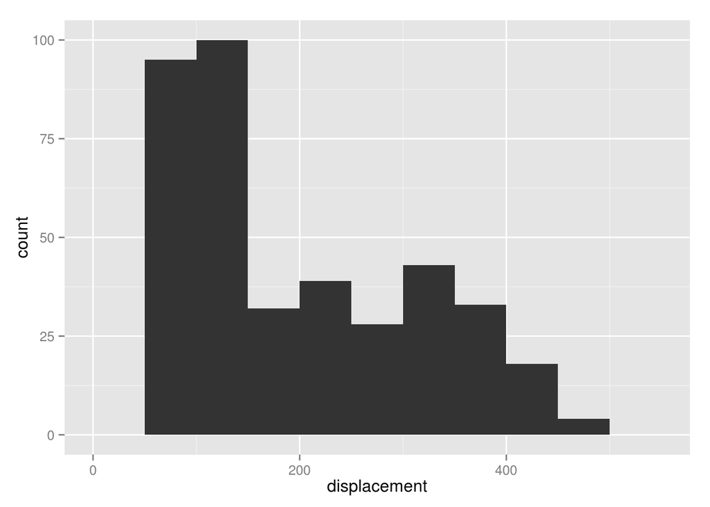

```r
qplot(displacement, data=auto, binwidth=50) # use "binwidth=50" to change
```

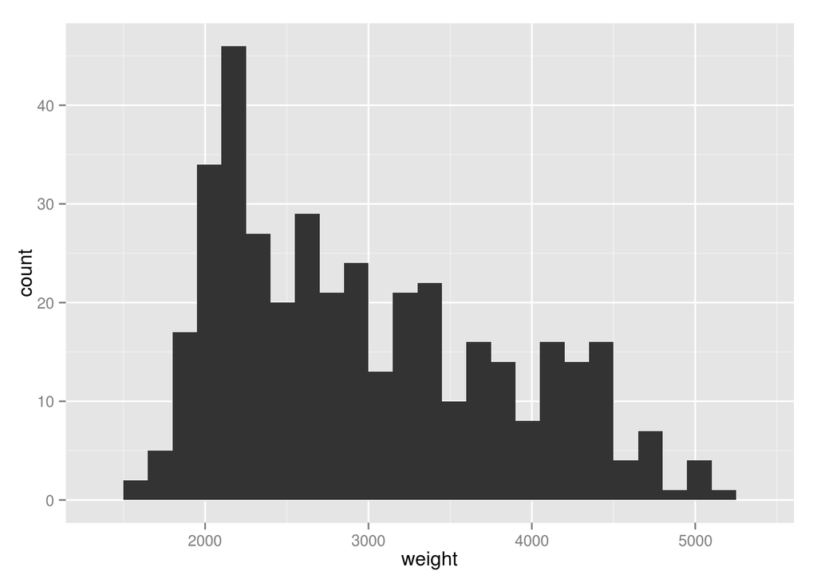

```r
qplot(weight, data=auto, binwidth=150)
```

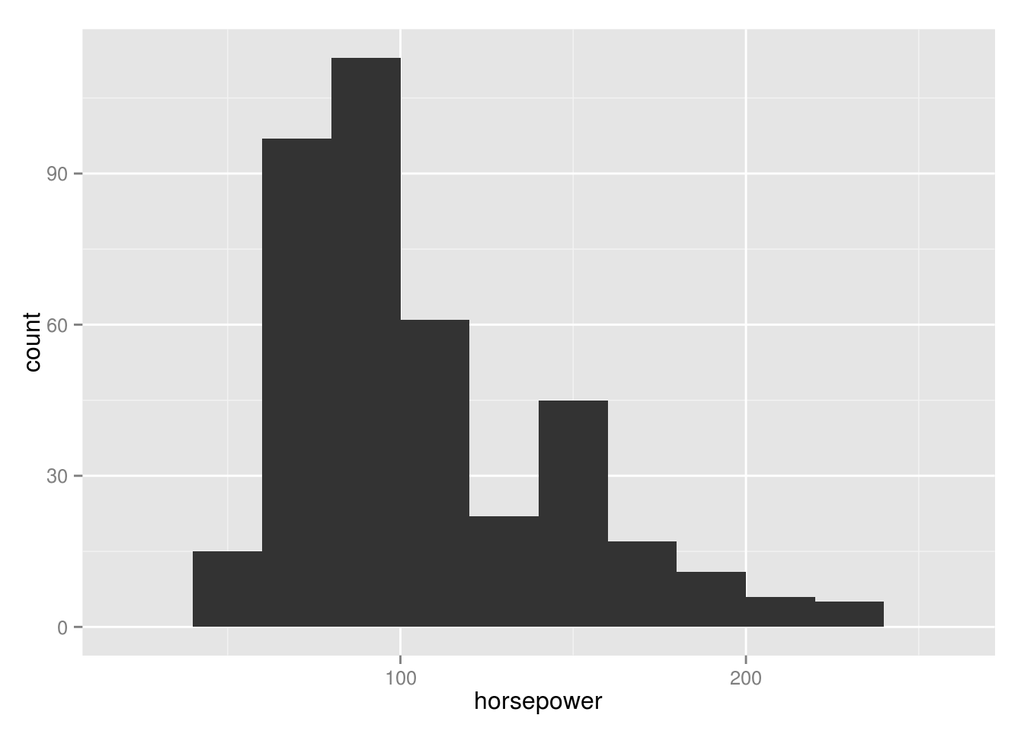

```r
qplot(horsepower, data=auto, binwidth=20)
```

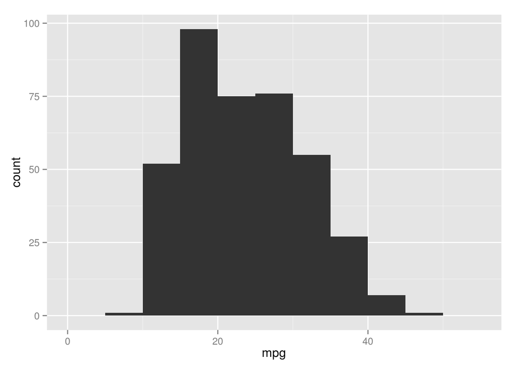

```r
qplot(mpg, data=auto, binwidth=5)
```

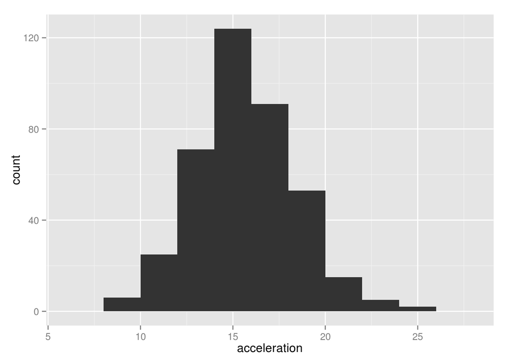

```r
qplot(acceleration, data=auto, binwidth=2)
```

Trying out some variable selection methods. I found these [here](http://www.statmethods.net/stats/regression.html). First, exhaustive search using “leaps” package:

```r
library(leaps)
# Regress on all variables except mpg and name.  Only 2^8 = 256 models!
leaps <- regsubsets(mpg ~ . - name, data=auto, method='exhaustive')
summary(leaps)
```

```
## Subset selection object
## Call: regsubsets.formula(mpg ~ . - name, data = auto, method = "exhaustive")
## 8 Variables  (and intercept)
##              Forced in Forced out
## cylinders        FALSE      FALSE
## displacement     FALSE      FALSE
## horsepower       FALSE      FALSE
## weight           FALSE      FALSE
## acceleration     FALSE      FALSE
## year             FALSE      FALSE
## origin2          FALSE      FALSE
## origin3          FALSE      FALSE
## 1 subsets of each size up to 8
## Selection Algorithm: exhaustive
##          cylinders displacement horsepower weight acceleration year
## 1  ( 1 ) " "       " "          " "        "*"    " "          " "
## 2  ( 1 ) " "       " "          " "        "*"    " "          "*"
## 3  ( 1 ) " "       " "          " "        "*"    " "          "*"
## 4  ( 1 ) " "       " "          " "        "*"    " "          "*"
## 5  ( 1 ) " "       "*"          " "        "*"    " "          "*"
## 6  ( 1 ) " "       "*"          "*"        "*"    " "          "*"
## 7  ( 1 ) "*"       "*"          "*"        "*"    " "          "*"
## 8  ( 1 ) "*"       "*"          "*"        "*"    "*"          "*"
##          origin2 origin3
## 1  ( 1 ) " "     " "
## 2  ( 1 ) " "     " "
## 3  ( 1 ) " "     "*"
## 4  ( 1 ) "*"     "*"
## 5  ( 1 ) "*"     "*"
## 6  ( 1 ) "*"     "*"
## 7  ( 1 ) "*"     "*"
## 8  ( 1 ) "*"     "*"
```

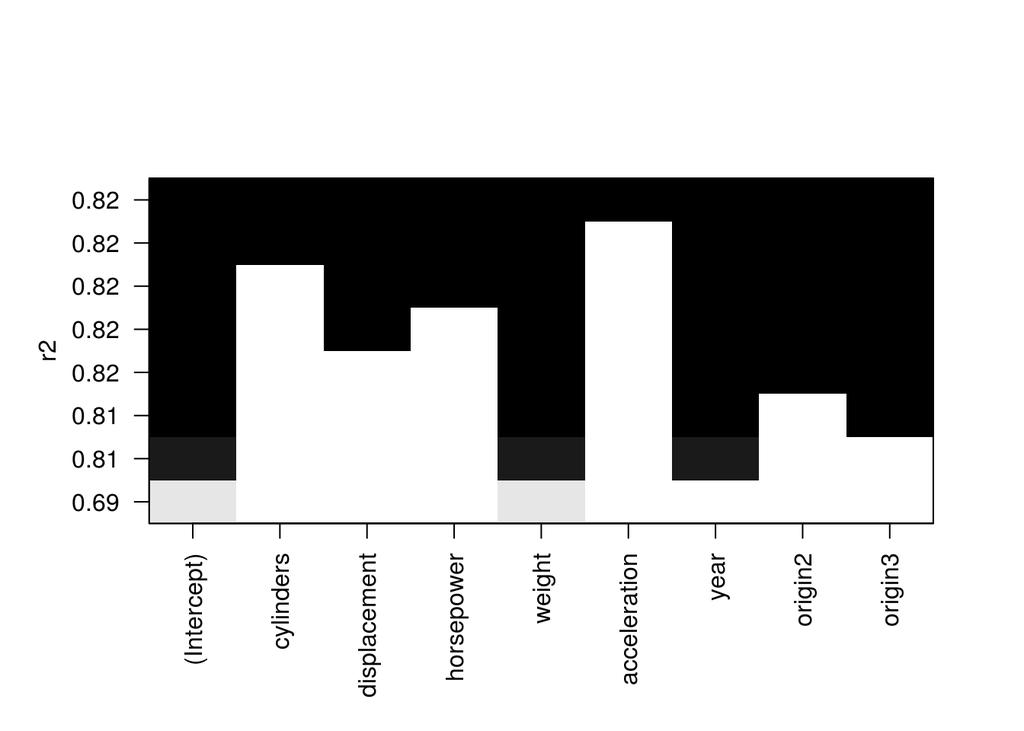

```r
plot(leaps, scale='r2')
```

```r
leaps$rss
```

```
## [1] 23819 22397 15915 10023  6076  5659  5423  4213  4187
```

Hm, that was interesting. It told me which was the best model for each subset size, but didn’t tell me how far to go. (TODO: maybe that information is embedded in the leaps object?) Next let’s try additive selection.

```r
fit <- lm(mpg ~ . - name, data=auto)
require(MASS)
step <- stepAIC(fit, direction='both')
```

```
## Start:  AIC=946.5
## mpg ~ (cylinders + displacement + horsepower + weight + acceleration +
##     year + origin + name) - name
##
##                Df Sum of Sq  RSS  AIC
## - acceleration  1         7 4194  945
## - horsepower    1        19 4207  946
## <none>                      4187  946
## - cylinders     1        25 4213  947
## - displacement  1       107 4295  954
## - origin        2       356 4543  974
## - weight        1      1147 5334 1039
## - year          1      2462 6649 1126
##
## Step:  AIC=945.1
## mpg ~ cylinders + displacement + horsepower + weight + year +
##     origin
##
##                Df Sum of Sq  RSS  AIC
## <none>                      4194  945
## - cylinders     1        27 4221  946
## + acceleration  1         7 4187  946
## - horsepower    1        59 4253  949
## - displacement  1       103 4297  953
## - origin        2       357 4552  973
## - weight        1      1373 5567 1054
## - year          1      2456 6650 1124
```

```r
step$anova # the "best" model includes everything but acceletation
```

```
## Stepwise Model Path
## Analysis of Deviance Table
##
## Initial Model:
## mpg ~ (cylinders + displacement + horsepower + weight + acceleration +
##     year + origin + name) - name
##
## Final Model:
## mpg ~ cylinders + displacement + horsepower + weight + year +
##     origin
##
##
##             Step Df Deviance Resid. Df Resid. Dev   AIC
## 1                                  383       4187 946.5
## 2 - acceleration  1    7.092       384       4194 945.1
```

```r
lower <- lm(mpg ~ 1, data=auto)
upper <- lm(mpg ~ . - name, data=auto)
step <- stepAIC(lower,
                scope=list(upper=upper, lower = lower),
                direction='forward')
```

```
## Start:  AIC=1612
## mpg ~ 1
##
##                Df Sum of Sq   RSS  AIC
## + weight        1     16498  7321 1151
## + displacement  1     15440  8379 1204
## + horsepower    1     14433  9386 1249
## + cylinders     1     14403  9416 1250
## + year          1      8028 15791 1453
## + origin        2      7904 15915 1458
## + acceleration  1      4269 19550 1537
## <none>                      23819 1612
##
## Step:  AIC=1151
## mpg ~ weight
##
##                Df Sum of Sq  RSS  AIC
## + year          1      2752 4569  969
## + horsepower    1       327 6994 1136
## + origin        2       224 7097 1143
## + acceleration  1       168 7153 1144
## + displacement  1       151 7170 1145
## + cylinders     1       115 7206 1147
## <none>                      7321 1151
##
## Step:  AIC=968.7
## mpg ~ weight + year
##
##                Df Sum of Sq  RSS AIC
## + origin        2     258.5 4310 950
## <none>                      4569 969
## + acceleration  1      10.5 4559 970
## + cylinders     1       5.0 4564 970
## + horsepower    1       3.3 4566 970
## + displacement  1       0.0 4569 971
##
## Step:  AIC=949.8
## mpg ~ weight + year + origin
##
##                Df Sum of Sq  RSS AIC
```

[output cut: 14 more lines]

```
##
## Step:  AIC=945.6
## mpg ~ weight + year + origin + displacement + horsepower
##
##                Df Sum of Sq  RSS AIC
## + cylinders     1     26.85 4194 945
## <none>                      4221 946
## + acceleration  1      8.53 4213 947
##
## Step:  AIC=945.1
## mpg ~ weight + year + origin + displacement + horsepower + cylinders
##
##                Df Sum of Sq  RSS AIC
## <none>                      4194 945
## + acceleration  1      7.09 4187 946
```

```r
step$anova
```

```
## Stepwise Model Path
## Analysis of Deviance Table
##
## Initial Model:
## mpg ~ 1
##
## Final Model:
## mpg ~ weight + year + origin + displacement + horsepower + cylinders
##
##
##             Step Df Deviance Resid. Df Resid. Dev    AIC
## 1                                  391      23819 1611.9
## 2       + weight  1 16497.76       390       7321 1151.5
## 3         + year  1  2752.28       389       4569  968.7
## 4       + origin  2   258.54       387       4310  949.8
## 5 + displacement  1    38.44       386       4272  948.3
## 6   + horsepower  1    50.63       385       4221  945.6
## 7    + cylinders  1    26.85       384       4194  945.1
```

A couple different selection methods arrive at the same model: all the predictors included except for acceleration. How about I work with that model for a bit:

```r
all.but.accel <- lm(mpg ~ . - name - acceleration, data=auto)
```

Well, it looks as if “cylinders” is not significant after including the other predictors. Let’s try without cylinders as well.

```r
minus.cylinders <- lm(mpg ~ displacement + horsepower + weight + year + origin, data=auto)
```

Everything is significant in this model.

```r
anova(all.but.accel, minus.cylinders) # TODO: interpret this.
```

```
## Analysis of Variance Table
##
## Model 1: mpg ~ (cylinders + displacement + horsepower + weight + acceleration +
##     year + origin + name) - name - acceleration
## Model 2: mpg ~ displacement + horsepower + weight + year + origin
##   Res.Df  RSS Df Sum of Sq    F Pr(>F)
## 1    384 4194
## 2    385 4221 -1     -26.9 2.46   0.12
```

Trying k-fold cross validation on the minus.cylinders model:

```r
require('DAAG')
cv.lm(df=auto[,-9], form.lm = minus.cylinders, m = 10) # gives error becuase of formula
```

```
## Analysis of Variance Table
##
## Response: mpg
##               Df Sum Sq Mean Sq F value  Pr(>F)
## displacement   1  15440   15440  1408.2 < 2e-16 ***
## horsepower     1    383     383    35.0 7.4e-09 ***
## weight         1   1015    1015    92.6 < 2e-16 ***
## year           1   2416    2416   220.3 < 2e-16 ***
## origin         2    343     171    15.6 3.0e-07 ***
## Residuals    385   4221      11
## ---
## Signif. codes:  0 '***' 0.001 '**' 0.01 '*' 0.05 '.' 0.1 ' ' 1
```

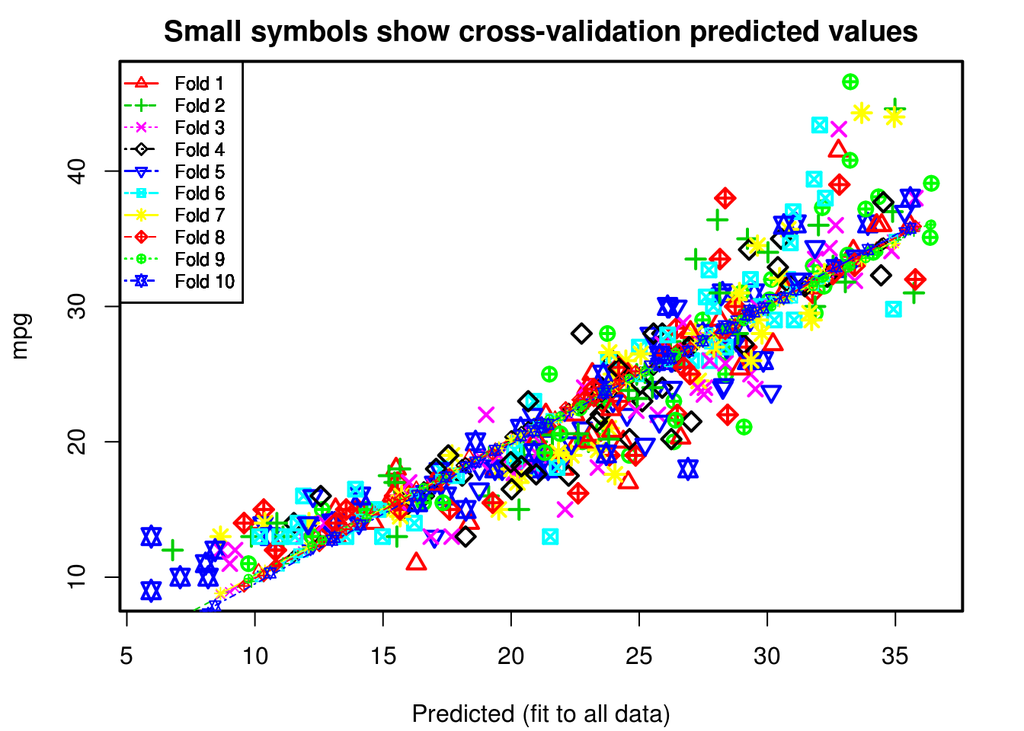

```
##
## fold 1
## Observations in test set: 39
##                 1     7    10     12    14    17     22   23       35
## Predicted   15.51 10.14 13.15 14.642 18.37 19.38 22.969 23.2 16.01248
## cvpred      15.58 10.53 13.47 14.853 18.97 19.43 23.168 23.4 15.99401
## mpg         18.00 14.00 15.00 14.000 14.00 18.00 24.000 25.0 16.00000
## CV residual  2.42  3.47  1.53 -0.853 -4.97 -1.43  0.832  1.6  0.00599
##                56    61     74    81   108   120   125    165    185
## Predicted   28.19 22.58 13.160 22.48 22.05 24.38 16.30 21.716 24.557
## cvpred      28.32 22.68 13.149 22.56 22.11 24.57 16.62 21.799 24.653
## mpg         27.00 20.00 13.000 22.00 18.00 20.00 11.00 21.000 25.000
## CV residual -1.32 -2.68 -0.149 -0.56 -4.11 -4.57 -5.62 -0.799  0.347
##                189    192    196   208    252   254   260   269   275
## Predicted   15.365 21.354 28.149 22.97 20.990 23.14 23.93 30.22 26.62
## cvpred      15.464 21.358 28.125 23.14 21.136 23.15 23.89 30.33 26.85
## mpg         16.000 22.000 29.000 20.00 20.200 20.50 20.80 27.20 20.30
## CV residual  0.536  0.642  0.875 -3.14 -0.936 -2.65 -3.09 -3.13 -6.55
##               276    290    295    308   310   320   360   362   364
## Predicted   24.57 16.956 33.356 26.024 32.78 30.71 27.00 28.93 23.90
## cvpred      24.86 17.055 33.351 26.228 32.98 30.66 27.05 29.05 23.95
## mpg         17.00 16.900 34.100 26.800 41.50 31.30 28.10 25.40 22.40
## CV residual -7.86 -0.155  0.749  0.572  8.52  0.64  1.05 -3.65 -1.55
##                375   380   381
## Predicted   35.559 34.46 34.27
## cvpred      35.782 34.56 34.28
## mpg         36.000 36.00 36.00
## CV residual  0.218  1.44  1.72
##
## Sum of squares = 369    Mean square = 9.47    n = 39
##
## fold 2
## Observations in test set: 40
##                 3    43    55    67   71     85    95    97    99   124
## Predicted   15.67  6.79 29.22 15.45 11.1 26.752  9.86 15.54 19.12 23.02
## cvpred      15.68  6.69 29.25 15.38 11.0 26.688  9.69 15.45 19.21 22.85
## mpg         18.00 12.00 35.00 17.00 13.0 27.000 13.00 13.00 16.00 20.00
## CV residual  2.32  5.31  5.75  1.62  2.0  0.312  3.31 -2.45 -3.21 -2.85
##                126   140   153   155   166    168   172    181   188
## Predicted   20.360 10.86 20.49 20.31 21.00 28.910 25.52 24.902 15.23
```

[output cut: 214 more lines]

```
## Predicted   23.60 17.47 14.12 29.23 19.37 21.44 27.487 18.61 16.341 29.84
## cvpred      23.61 17.41 13.86 29.37 19.37 21.29 27.463 18.51 16.028 29.89
## mpg         25.00 16.00 16.00 26.00 18.00 18.00 28.000 20.00 15.500 26.00
## CV residual  1.39 -1.41  2.14 -3.37 -1.37 -3.29  0.537  1.49 -0.528 -3.89
##               246   247  249   253    315   317    368   385   391
## Predicted   31.12 32.69 33.9 20.90 25.792 23.71 28.646 35.58 30.64
## cvpred      31.23 32.94 34.2 20.82 25.638 23.79 28.444 35.77 30.63
## mpg         36.10 32.80 36.1 19.20 26.400 19.10 28.000 38.00 36.00
## CV residual  4.87 -0.14  1.9 -1.62  0.762 -4.69 -0.444  2.23  5.37
##
## Sum of squares = 408    Mean square = 10.4    n = 39
##
## Overall (Sum over all 39 folds)
##   ms
## 11.2
```

```r
mod <- lm(mpg ~ displacement + horsepower + weight + year + origin, data=auto)
```

The cv.lm function divides the data randomly into folds. By turn, each fold is predicted using a model regressed on the other folds. I believe this gives the cvpred column. The Predicted column is predictions based on all the data?

```r
huh <- cv.lm(df=auto[,-9], form.lm = mod, m = 5, printit=F)
```

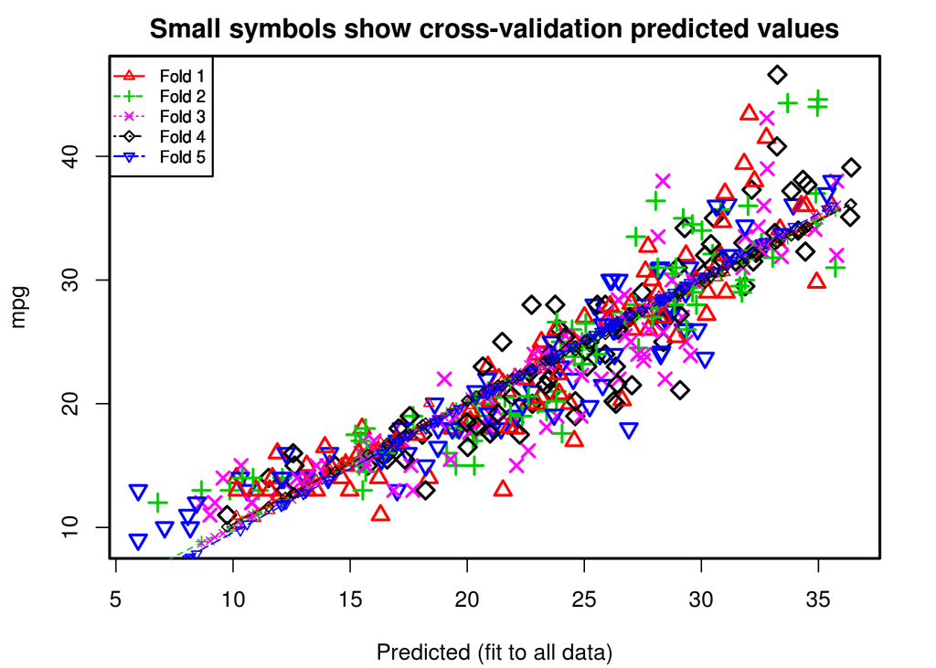

```r
sum((huh$mpg - huh$cvpred)^2)/dim(huh)[1] # the average mean-squared-error of cross-validation?
```

```
## [1] 11.2
```

10. Housing values in Suburbs of Boston. TODO: answer their questions.

The rows appear to represent “suburbs,” or neighborhoods, of Boston.

```r
library(MASS)
data(Boston)
str(Boston)
```

```
## 'data.frame':    506 obs. of  14 variables:
##  $ crim   : num  0.00632 0.02731 0.02729 0.03237 0.06905 ...
##  $ zn     : num  18 0 0 0 0 0 12.5 12.5 12.5 12.5 ...
##  $ indus  : num  2.31 7.07 7.07 2.18 2.18 2.18 7.87 7.87 7.87 7.87 ...
##  $ chas   : int  0 0 0 0 0 0 0 0 0 0 ...
##  $ nox    : num  0.538 0.469 0.469 0.458 0.458 0.458 0.524 0.524 0.524 0.524 ...
##  $ rm     : num  6.58 6.42 7.18 7 7.15 ...
##  $ age    : num  65.2 78.9 61.1 45.8 54.2 58.7 66.6 96.1 100 85.9 ...
##  $ dis    : num  4.09 4.97 4.97 6.06 6.06 ...
##  $ rad    : int  1 2 2 3 3 3 5 5 5 5 ...
##  $ tax    : num  296 242 242 222 222 222 311 311 311 311 ...
##  $ ptratio: num  15.3 17.8 17.8 18.7 18.7 18.7 15.2 15.2 15.2 15.2 ...
##  $ black  : num  397 397 393 395 397 ...
##  $ lstat  : num  4.98 9.14 4.03 2.94 5.33 ...
##  $ medv   : num  24 21.6 34.7 33.4 36.2 28.7 22.9 27.1 16.5 18.9 ...
```

```r
# ?Boston
dim(Boston)
```

```
## [1] 506  14
```

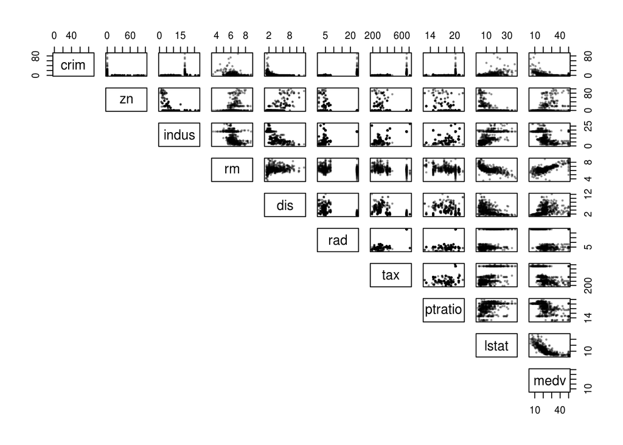

```r
# pairs(Boston)
pairs(Boston[,c(1,2,3,6,8,9,10,11,13,14)], lower.panel = {},
      pch=20, cex=.5, col=rgb(0,0,0,.3))
```

Something inexplicable.

The help, found by “?Boston”, says that the “black” variable is 1000*(Bk - 0.63)^2, where Bk is the proportion of blacks in the town. So, why do most of them have a Bk greater than 1?? “black” is exactly 396.9 (the highest value) for exactly 121 suburbs. I just can’t figure out their crazy transformation of this variable.

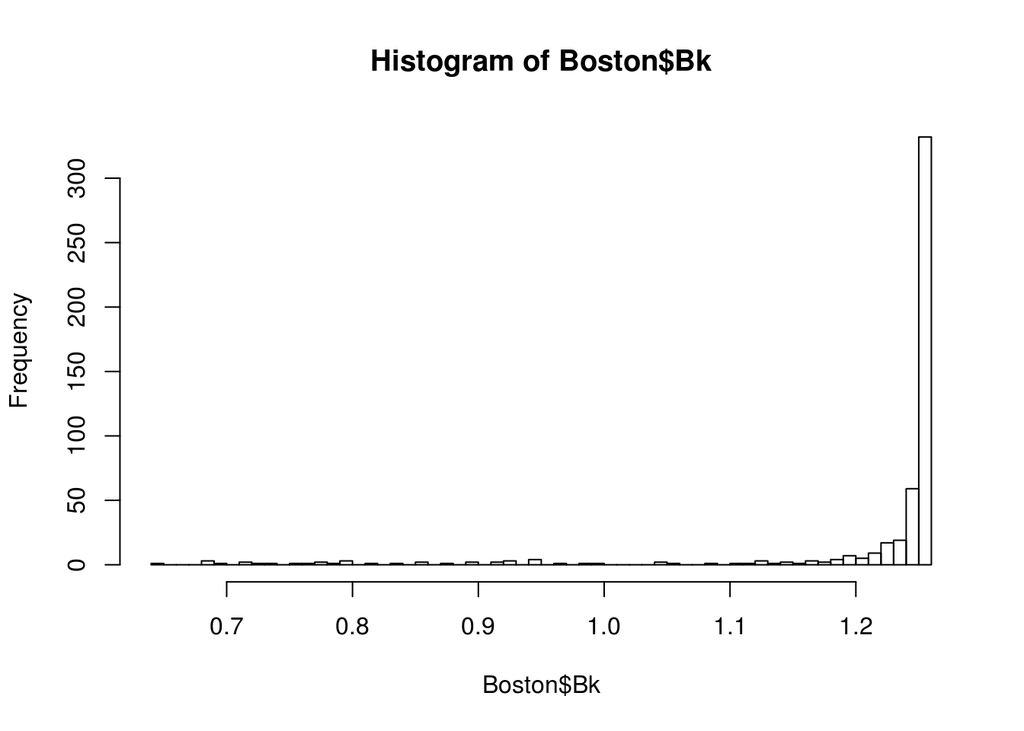

```r
Boston$Bk <- 0.63 + sqrt(Boston$black/1000)
hist(Boston$Bk, breaks=50)
```

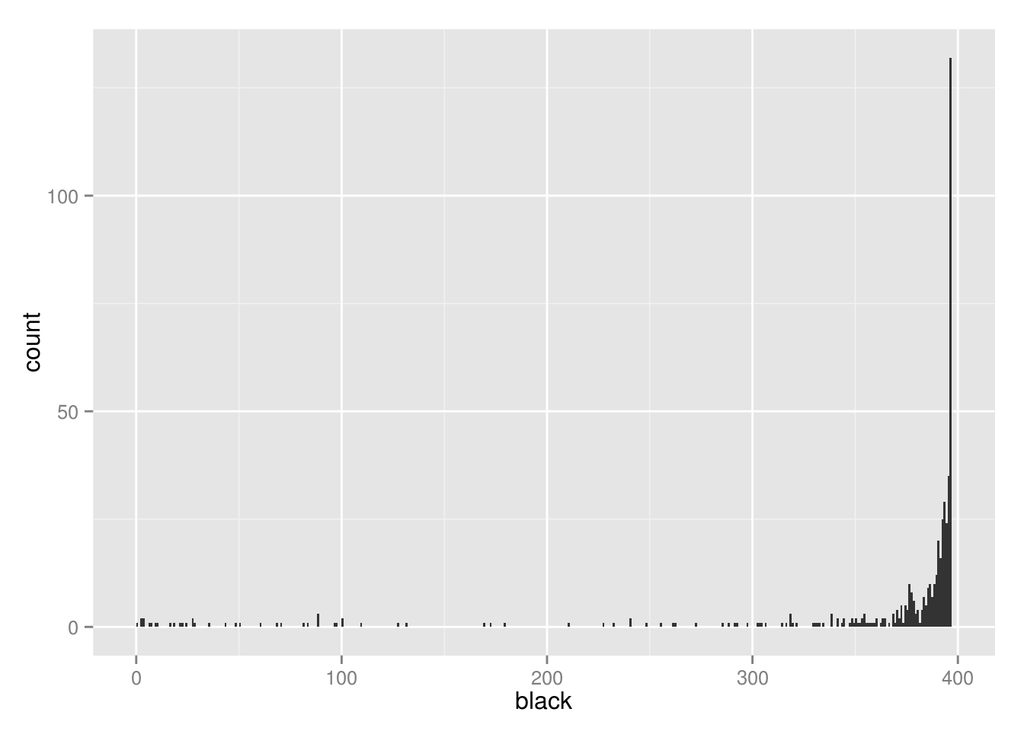

```r
qplot(black, data=Boston, binwidth=1)
```

```r
with(Boston, sum(black == 396.9))
```

```
## [1] 121
```

The crime rate is highly, highly skewed.

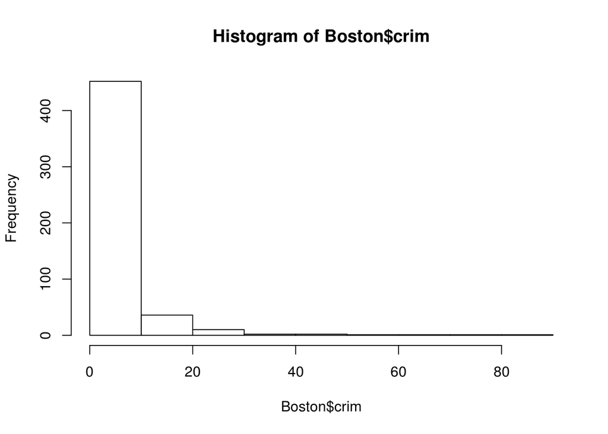

```r
hist(Boston$crim)
```

```r
crime.ridden <- Boston[ Boston$crim > 30, ] # not sure what I'm seeing here
```

372 of the 506 Boston suburbs have zn = 0 (zn is the proportion of residential land zoned for lots over 25,000 sq ft). The remaining 134 suburbs have skewed zone as well.

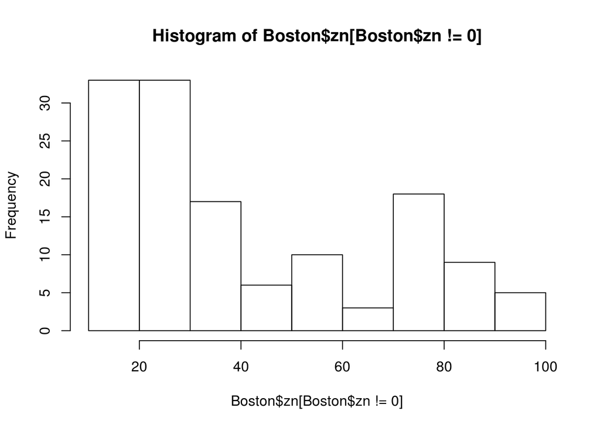

```r
hist(Boston$zn[ Boston$zn != 0])
```

```r
summary(Boston$crim[ Boston$zn != 0]) # when zn != 0, crime rate is small, still skewed
```

```
##    Min. 1st Qu.  Median    Mean 3rd Qu.    Max.
##   0.006   0.036   0.063   0.130   0.128   0.825
```

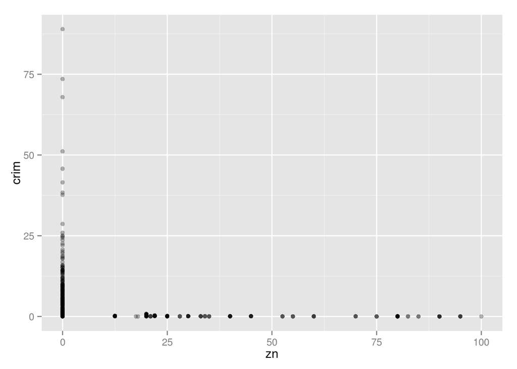

```r
ggplot(Boston, aes(zn, crim)) + geom_point(alpha=.3) # the crime happens in zn = 0 neighborhoods
```

There are 132 suburbs (about 26%) that have *exactly* 18.1 for “indus” (proportion of non-retail business acres per town). And hold it… the same 132 suburbs have identical values in several other variables as well. This suggests to me that during data collection or cleaning, these values were averaged together or otherwise botched. Wouldn’t this cause problems for analysis? Should these values be treated as missing?

```r
 # start with these 132:
with(Boston, sum(indus == 18.1))
```

```
## [1] 132
```

```r
# still those 132!
sum(Boston$rad == 24) # exactly 132
```

```
## [1] 132
```

```r
sum(Boston$tax == 666) # exactly 132
```

```
## [1] 132
```

```r
sum(Boston$ptratio == 20.2) # 140, nearly 132.  Really, exact equality for a decimal value?
```

```
## [1] 140
```

```r
with(Boston, sum((indus == 18.1) &
                     (zn == 0) & # (actually this is almost to be expected)
                     (rad == 24) &
                     (tax=666) &
                     (ptratio=20.2)))
```

```
## [1] 132
```

A pretty histogram:

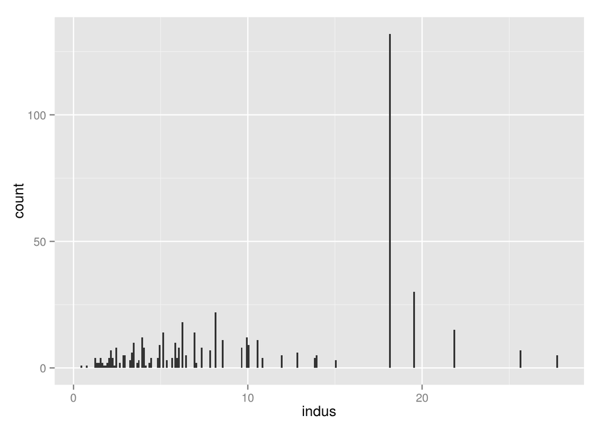

```r
qplot(indus, data=Boston, binwidth=.1)
```

Some of the variables should really be logged. With logged dis and crim, a negatively-sloped linear model would work well.

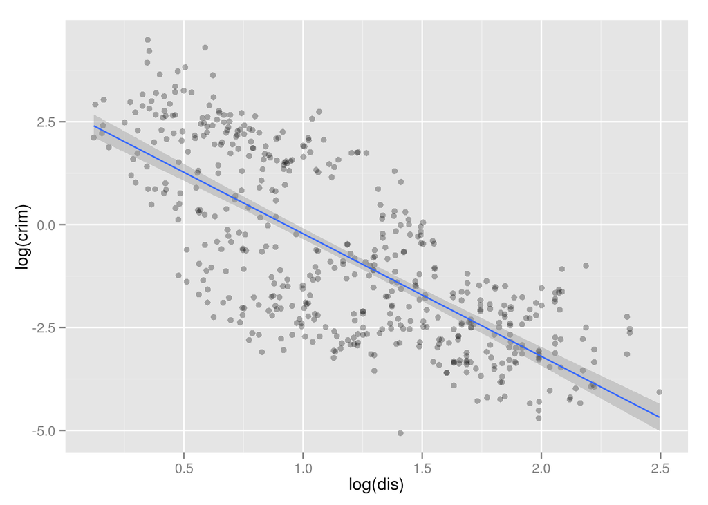

```r
ggplot(Boston, aes(log(dis), log(crim))) +
    geom_point(alpha=.3) + geom_smooth(method='lm')
```

```r
    ggtitle('log(crim) vs log(dis)')
```

```
## $title
## [1] "log(crim) vs log(dis)"
##
## attr(,"class")
## [1] "labels"
```